# Dec_trees

## Jorge Bueno Perez - 419034

## Prediction of the average price of the Spanish rail tickets data

```python
import numpy as np
import pandas as pd
import os
import time
from sklearn import decomposition
from sklearn import metrics
from sklearn import tree
from sklearn.pipeline import Pipeline
from sklearn.tree import DecisionTreeRegressor
from sklearn.model_selection import train_test_split, GridSearchCV, cross_val_score
from sklearn.metrics import r2_score, roc_curve, roc_auc_score, confusion_matrix
from sklearn.preprocessing import StandardScaler
import matplotlib.pyplot as plt
import joblib
```

```python
renfe = pd.read_csv("~/Desktop/Projects/DL/Regression/Before_modeling/Datasets/renfe2.csv")
```

# 0) `Spliting the data`

### In this first model the data will be splitted as per below:

- `20%` - `test data`
- `80%` - `train data`

### `X` are the regressors, hence the following `9 features`:

- `origin`
- `destination`
- `duration`
- `vehicle_type`
- `fare`
- `week_day`
- `month`
- `time`
- `distance`

### `y` is the target variable, `price`

```python
X = renfe.drop(["price"],1).astype(int) #Feature Matrix
y = renfe["price"] #Target Variable
```

```python
#X_train, X_test, y_train, y_test = train_test_split(X, y, test_size=0.2)
```

```python
#X_train.to_csv("~/Desktop/Projects/DL/Regression/X_train.csv", index=False)
#X_test.to_csv("~/Desktop/Projects/DL/Regression/X_test.csv", index=False)
#y_train.to_csv("~/Desktop/Projects/DL/Regression/y_train.csv", index=False)
#y_test.to_csv("~/Desktop/Projects/DL/Regression/y_test.csv", index=False)
```

### These above `explits` are going to be `used in the rest of the models`

# 1) `Model without Cross Validation` - `Decision trees`

### Firstly, a model `without a cross validation` will be run. In such way it will be possible to see a `representation of the decision tree`, which will have the `maximum depth` assigned equal to `3`

```python
X_train = pd.read_csv("~/Desktop/Projects/DL/Regression/Modeling/data_splits/X_train.csv")
X_test = pd.read_csv("~/Desktop/Projects/DL/Regression/Modeling/data_splits/X_test.csv")
y_train = pd.read_csv("~/Desktop/Projects/DL/Regression/Modeling/data_splits/y_train.csv")
y_test = pd.read_csv("~/Desktop/Projects/DL/Regression/Modeling/data_splits/y_test.csv")
```

```python
clf_ = tree.DecisionTreeRegressor(max_depth=3, random_state=123)
clf_.fit(X_train, y_train)
```

```
DecisionTreeRegressor(max_depth=3, random_state=123)
```

```python
clf_.get_params()
```

```
{'ccp_alpha': 0.0,
 'criterion': 'mse',
 'max_depth': 3,
 'max_features': None,
 'max_leaf_nodes': None,
 'min_impurity_decrease': 0.0,
 'min_impurity_split': None,
 'min_samples_leaf': 1,
 'min_samples_split': 2,
 'min_weight_fraction_leaf': 0.0,
 'presort': 'deprecated',
 'random_state': 123,
 'splitter': 'best'}
```

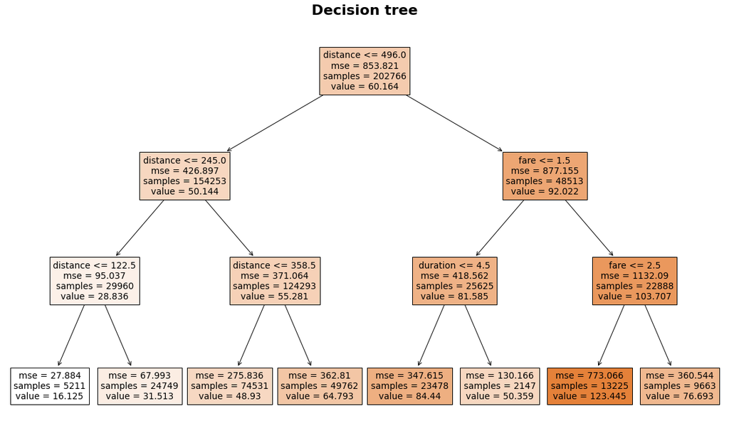

```python
fig = plt.figure(figsize=(20,12))
_ = tree.plot_tree(clf_,
                   feature_names= renfe.columns.tolist()[:9],
                   class_names= ["price"],
                   filled=True)
plt.title('Decision tree',
            fontsize=22,
            fontweight='bold')
plt.savefig('Figures/dec_tree.png')
```

### Above a representation of the `decision tree` can be seen

# 2) `Model with Cross Validation` - `Decision trees`

```python
std_slc = StandardScaler()
pca = decomposition.PCA()
dtreeReg = tree.DecisionTreeRegressor(random_state=123)
```

```python
dtreeReg.get_params()
```

```
{'ccp_alpha': 0.0,
 'criterion': 'mse',
 'max_depth': None,
 'max_features': None,
 'max_leaf_nodes': None,
 'min_impurity_decrease': 0.0,
 'min_impurity_split': None,
 'min_samples_leaf': 1,
 'min_samples_split': 2,
 'min_weight_fraction_leaf': 0.0,
 'presort': 'deprecated',
 'random_state': 123,
 'splitter': 'best'}
```

## 2.1) `Training` model

### This model is going to be `tuned` with different parameters of `max depth`, [2, 4, 6 ... 18]

```python
params = {'max_depth': [2, 4, 6, 8, 10, 12, 14, 16, 18]}

tree_regressor_grid = GridSearchCV(dtreeReg, param_grid =params, cv=3, n_jobs=-1)
tree_regressor_grid.fit(X_train, y_train)

print('Best Parameters : ',tree_regressor_grid.best_params_)
```

```
Best Parameters :  {'max_depth': 14}
```

### It seems the best model has the `max depth` equal to `14`

```python
joblib.dump(tree_regressor_grid, "tree_regressor_grid.sav")
```

```
['tree_regressor_grid.sav']
```

## 2.2) `Prediction on the test sample`

```python
tree_regressor_grid = joblib.load("tree_regressor_grid.sav")
```

```python
renfe.columns
```

```
Index(['origin', 'destination', 'duration', 'vehicle_type', 'fare', 'week_day',
       'month', 'time', 'distance', 'price'],
      dtype='object')
```

```python
y_pred = tree_regressor_grid.predict(X_test)
```

```python
print('Mean Absolute Error', metrics.mean_absolute_error(y_test, y_pred))
```

```
Mean Absolute Error 6.648778723526535
```

```python
print('Root Mean Squared Error', np.sqrt(metrics.mean_squared_error(y_test, y_pred)))
```

```
Root Mean Squared Error 11.644507342199514
```

```python
print('R Squared Score is:', r2_score(y_test, y_pred))
```

```
R Squared Score is: 0.8393470283966108
```

## 2.3) `Prediction on the train sample`

```python
y_pred_ = tree_regressor_grid.predict(X_train)
```

```python
print('Mean Absolute Error', metrics.mean_absolute_error(y_train, y_pred_))
```

```
Mean Absolute Error 6.247150604189607
```

```python
print('Root Mean Squared Error', np.sqrt(metrics.mean_squared_error(y_train, y_pred_)))
```

```
Root Mean Squared Error 10.989727931983092
```

```python
print('R Squared Score is:', r2_score(y_train, y_pred_))
```

```
R Squared Score is: 0.8585486251722246
```

## 2.4) `Graphical results`

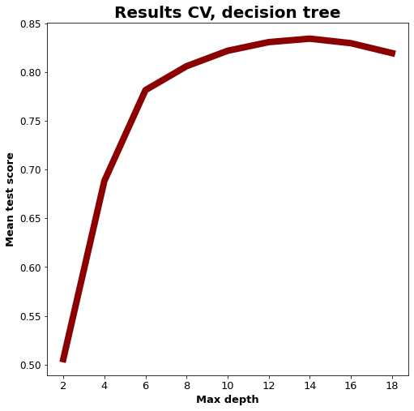

```python
import seaborn as sns
import matplotlib.pyplot as plt
fig, ax = plt.subplots(figsize=(8,8))
plt.plot(tree_regressor_grid.cv_results_['param_max_depth'].tolist(), tree_regressor_grid.cv_results_['mean_test_score'].tolist(), lw=8, color= "darkred")
ax.set_title("Results CV, decision tree", fontsize=20, fontweight="bold")
ax.tick_params(axis='x', labelsize=13)
ax.tick_params(axis='y', labelsize=12)
plt.xlabel('Max depth', fontsize=13, fontweight="bold")
plt.ylabel('Mean test score', fontsize=13, fontweight="bold")
fig.savefig('Figures/cv_dec_tree.png')
plt.show()
```

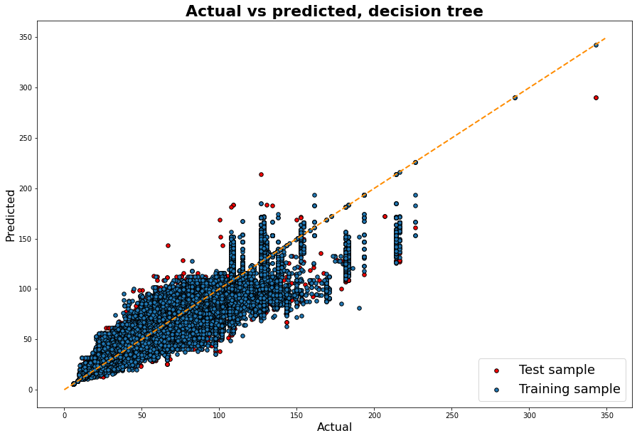

```python
import matplotlib.pyplot as plt
fig, (ax1) = plt.subplots(figsize=(15,10))

plt.title('Actual vs predicted, decision tree', fontsize=22,
            fontweight='bold')

ax1.scatter(y_test, y_pred, edgecolors=(0, 0, 0), color= "red", s=30, label='Test sample')
ax1.plot(range(350), 'k--', lw=2, color= "darkorange")
ax1.set_xlabel('Actual', fontsize=16)
ax1.set_ylabel('Predicted', fontsize=16)

ax1.scatter(y_train, y_pred_, edgecolors=(0, 0, 0), s=30,label='Training sample')

ax1.legend(loc=4, fontsize=18)
plt.show()
fig.savefig('Figures/cv_pred_err_tree.png')
```

```python
tree_regressor_grid.predict(np.array([1, 2, 3, 4, 5, 6, 7, 8, 9]).reshape(1, -1)) # to make a predition
```

```
array([24.6])
```

# 3) `Conclusions`

### The best parameter for the model is `max depth` equal to `14`

### It seems there is `not a lot of difference` between the `R squared score` of the `test` and `training` samples

### In order to compare the models `R squared score of the test sample` will be taken, which is equal to `83.93%`